# CytoSeen Report

This report compiled libraries and has details pertaining to:

- Sites retained after filtering for missingness threshold.
- Sites retained using various missingness thresholds.
- Intra- vs Inter- sample correlations of 5mC.
- PCA of batch effects.

In this analysis there were **6 libraries** with a **maximum of 10% missing libraries** to retain a site. Each site was sequenced to at least **20X** and at most **200X**.

## Site Retainment

Filter according to the specified **0.1 missingness** threshold.

A total of **1420115** sites were assayed. After retaining sites missing in less than 0.1 samples, there were **76862 sites**, leaving **5.4%** of sites.

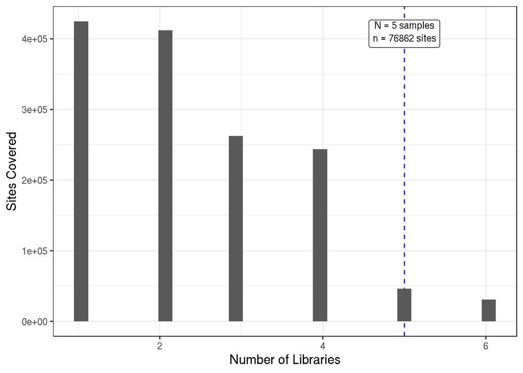

Site missingness across all samples.

## Site Missingness Sensitivity

Assessment of how many sites would be retained across various missingness thresholds.

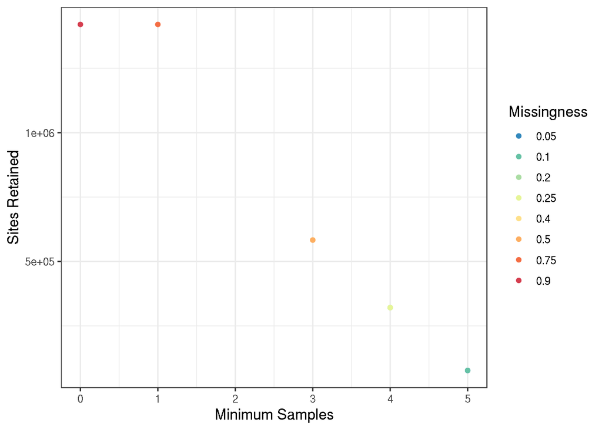

Which libraries have the most sites sequenced within coverage thresholds?

| runid | bioid | batchid | filtered_sites |
| --- | --- | --- | --- |
| B2X4825_BL_ADL_M__SRR25143963 | B2X4825_BL_ADL_M | Kiel_EMSeq_MspI | 934326 |
| B2X3498_BL_ADL_M__SRR25143974 | B2X3498_BL_ADL_M | Kiel_EMSeq_MspI | 898362 |
| B2V8841_BL_ADL_F__SRR25143965 | B2V8841_BL_ADL_F | Kiel_EMSeq_MspI | 450185 |
| B2X4825_BL_ADL_M__SRR10606826 | B2X4825_BL_ADL_M | Kiel_RRBS | 417423 |
| B2X4825_BL_ADL_M__SRR10606843 | B2X4825_BL_ADL_M | Kiel_RRBS | 370708 |
| B2X3498_BL_ADL_M__SRR25143972 | B2X3498_BL_ADL_M | Kiel_EMSeq_MspI | 355932 |

## Correlations

Assess correlations between technical replicates (*intra-sample*) and among all biosamples (*inter-sample*). This is done using the following framework:

1. Subset a runid (replicate) for a bioid (biological replicate)
2. Subset one of its other runids
3. Subset n=1,000 sites, and calculate Spearman’s correlation using ‘complete.obs’
4. Use `boot` to repeat the above using 1,000 resampling events
5. Grab an inter-sample comparison (bioid != bioid), and `boot` the correlation again on 1,000 sites
6. Repeat for each runid, and for each bioid

### Inter- vs Intra- sample Correlations

The plot below shows the 95% CI inter-sample correlations with black error bars and the 95% CIs for all intra-sample (technical replicates) correlations with colors. Colors are assigned based on the batch IDs of each replicate.

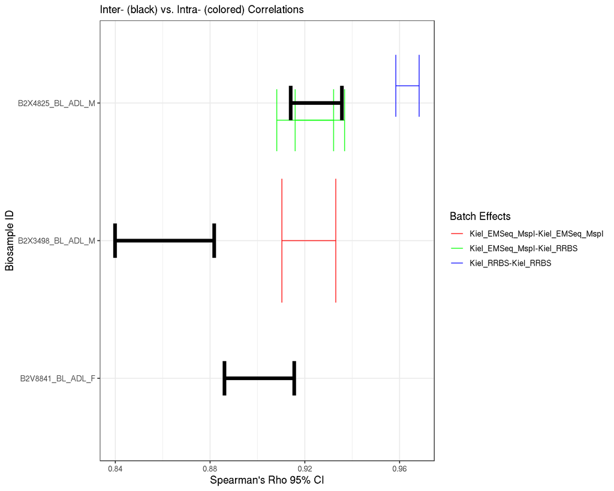

### Intra-sample correlations across batches

Is there a relationship with batch? This plot shows each batch comparison along the Y-axis (e.g. FirstBatchID - SecondBatchID), and the 95% CI midpoint from all respective comparisons.

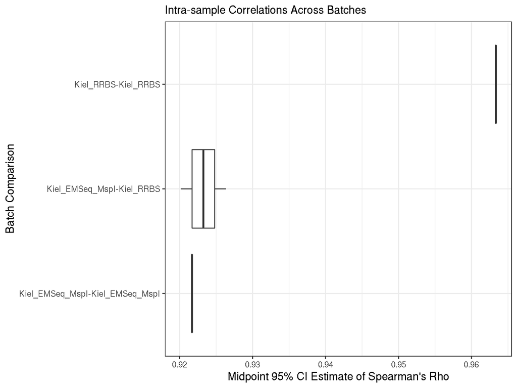

### Overall Intra- vs Inter- sample Correlations

Overall, what are the inter- and intra- sample correlations? This plot shows the midpoint of the 95% CIs for each contrast (`mutate(midpoint = (lower + upper) / 2)`). This will output *n* = biosample values for `Inter-sample` comparisons, while intra- sample comparisons will depend on the number of replicates available for each biosample.

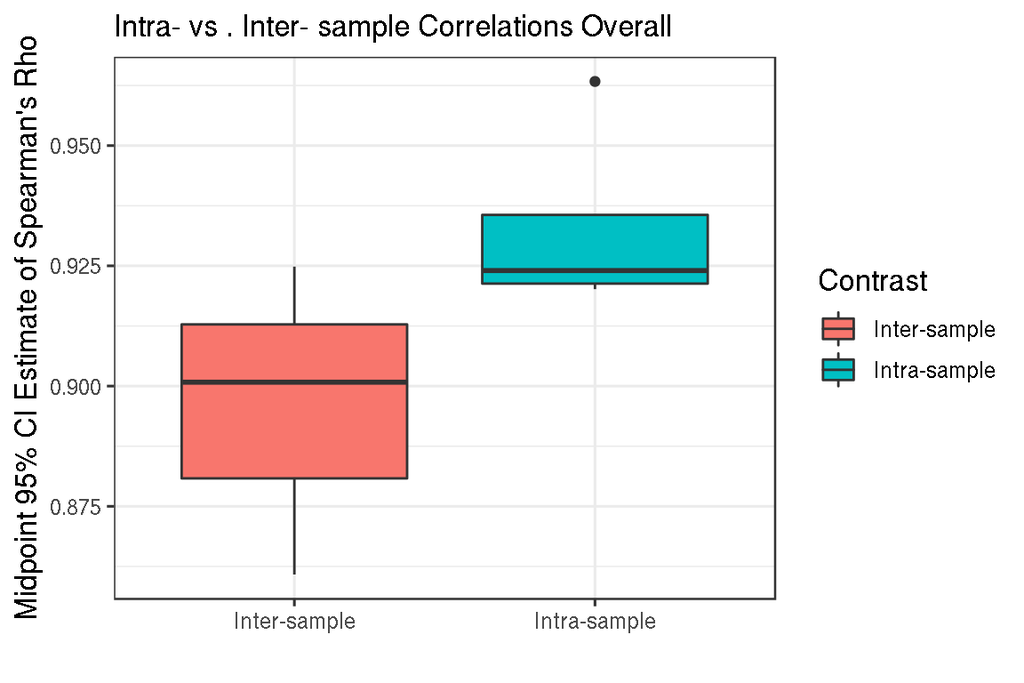

## Batch Effects

### PCA Assessment

Using the retained and filtered sites, impute missing data with [missMDA](https://doi.org/10.18637/jss.v070.i01) and perform a PCA. The plot below shows axes 1-4, colored according to batch effects.

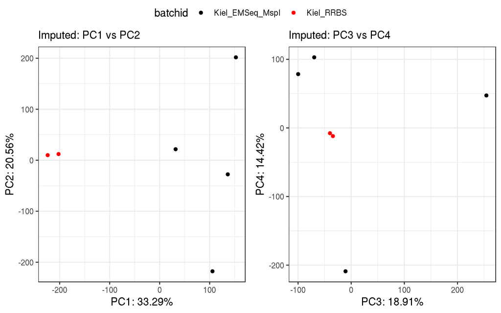

### Quantifying Batch Effects

Batch effects can be quantified directly with a RDA using vegan. The model is `rda(pc_axes ~ batchid)`.

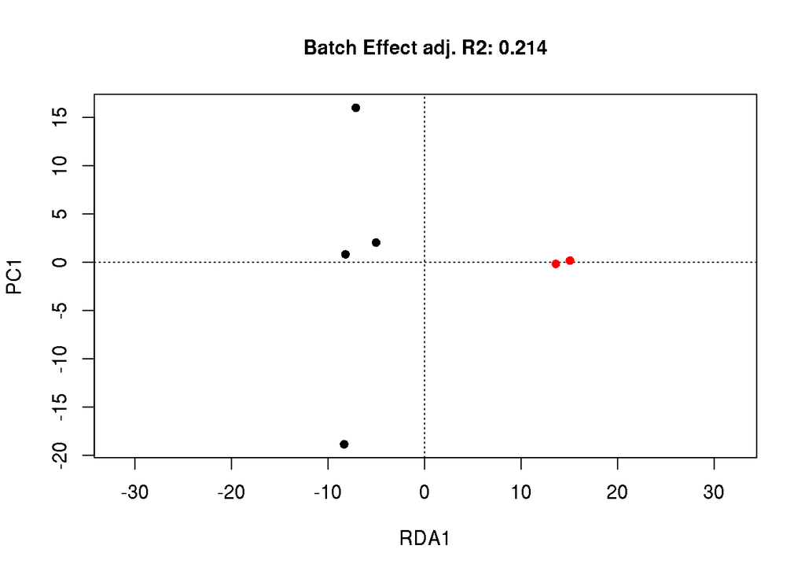